# **secr** simulations RSF

Murray Efford

2024-06-14

# Spatially autocorrelated random effects RSF and SARE

The simulations described here are part of a series documenting the effect of breaching assumptions of spatially explicit capture–recapture models.

Unmodelled spatial variation in the probability of detection is a potential cause of bias in density estimates from null-model SECR. There are subtleties here: we may be talking about either

1. The probability of detecting an animal at any detector, given its AC, or
2. The probability that a detector will detect an animal given its presence in the vicinity

The second involves a property of the detector that may vary independently of other detectors or in a spatially autocorrelated fashion (hence ‘spatially autocorrelated random effects’ or SARE following Dey et al. (2023)). Several papers have simulated detector variation as resulting from a Gaussian random field. The field is defined across continuous space, but evaluated only at the detector locations, for which the variation is multivariate normal (MVN). Spatial autocorelation is determined by the covariance function (usually exponential) and its spatial scale. Distances between detectors are multiplied by the covariance spatial scale parameter for which we use the symbol $\phi$.

The cases identified by Dey et al. (2023:3) are:

| Case | Label | Interpretation |
| --- | --- | --- |
| $\phi = 0$ | SCR | no heterogeneity, detectors identical |
| $0 < \phi < \infty$ | SARE | spatially autocorrelated random effect |
| $\phi \to \infty$ | RE | independent random effect each detector RE |

A cumulative effect of detector-level variation (2) is to drive differences in detection probability among animals (1). This is because an AC is likely to be exposed to a unique set of nearby detectors. Detector variation may bias density estimates from a null model purely because of this individual heterogeneity, although we will see that this is hard to pin down.

Here we reproduce selected RSF simulations from the paper of Royle et al. (2013). The RSF model is unrealistic as a model of animal activity as it posits potentially large variation among individuals in total activity. It is biologically more realistic to normalise activity using an integral of the underlying Gaussian random field (Efford 2014), and we include some relevant simulations.

The SARE simulations of Moqanaki et al. (2021) and Dey et al. (2023) are treated in a separate Rmarkdown document secr-simulations-SARE.rmd. That document also compares parameterisations of the GRF and mentions extensions.

## Package version, date and platform

```r
source('../setup.R')   # sets options(nrepl,nrepl2)
source('../Moran.R')
runsim  <- FALSE
cache   <- TRUE
figures <- TRUE
nrepl   <- 100
nrepl2  <- 500
metadata(runsim)       # if FALSE picks up saved metadata.RDS
library(mvtnorm)
library(raster)
library(RandomFields)
```

```
## R version 4.3.2 (2023-10-31)
## Platform   x86_64-pc-linux-gnu (64-bit)
## Running    CentOS Linux 7 (Core)
## secr       4.6.7 2024-05-18
## secrdesign 2.9.1 2024-05-18
## Threads    39
## nrepl      100
## nrepl2     500
## Run        Thu Jun 13 08:52:15 2024
```

# Royle et al. 2013 RSF

## Alternative capthist simulator

```r
simRSF.capthist <- function (traps, popn, detectfn, detectpar, noccasions = 10,
                             alpha2 = 1, scale = 1, ...)
{
    if (!(detectfn == 14 || detectfn == "HHN")) stop ("detectfn not implemented")
    K <- nrow(traps)
    cov <- exp(-edist(traps,traps)/scale)
    X <- mvtnorm::rmvnorm(1, mean = rep(0, K), sigma = cov)
    alpha0 <- log(detectpar$lambda0)
    lambda0 <- exp(alpha0 + alpha2 * X)       # length K vector
    # lambda0 input to sim.capthist is matrix noccasions x ndetectors
    detectpar$lambda0 <- matrix(lambda0, byrow = TRUE, nrow = noccasions, ncol = K)
    covariates(traps) <- data.frame(X = as.numeric(X))
    ch <- sim.capthist(traps, popn, detectfn, detectpar, noccasions)
    attr(ch, 'X') <- X
    attr(ch, 'lambda0') <- lambda0
    ch
}
```

```r
grid49 <- make.grid(7,7, spacing = 5, detector = 'proximity')
mask49 <- make.mask(grid49, buffer = 8)
poparg <- list(Ndist = 'fixed')
detarg <- expand.arg(alpha2        = 1.0,  # coefficient of random effect
                     scale         = 5)    # scale of covariance
fitarg <- list(list(model    = lambda0~1,
                    detectfn = 'HHN',
                    details  = list(distribution = 'binomial')),
               list(model    = lambda0~X,
                    detectfn = 'HHN',
                    details  = list(distribution = 'binomial')))
scen <- make.scenarios(noccasions = 10,
                       D          = c(100,200)/maskarea(mask49),
                       lambda0    = exp(-2),   # exp(alpha0)
                       sigma      = 2,
                       detectfn   = 'HHN',
                       detindex   = 1:length(detarg),
                       fitindex   = 1:2)
```

```r
scenarioSummary(scen, trapset = grid49)
```

```
##   scenario trapsindex noccasions nrepeats      D lambda0 sigma detectfn     En     Er     Em    En2
## 1        1          1         10        1 472.59 0.13534     2       14 45.391 30.785 14.315 11.774
## 2        2          1         10        1 945.18 0.13534     2       14 90.782 61.569 28.630 23.548
## 3        3          1         10        1 472.59 0.13534     2       14 45.391 30.785 14.315 11.774
## 4        4          1         10        1 945.18 0.13534     2       14 90.782 61.569 28.630 23.548
##        esa CF rotRSE rotRSEB arrayN arrayspace arrayspan saturation detperHR.median       k
## 1 0.096048  1 0.1802  0.1488     49        2.5    21.213    0.14849               2 0.43478
## 2 0.096048  1 0.1274  0.1052     49        2.5    21.213    0.27492               2 0.61488
## 3 0.096048  1 0.1802  0.1488     49        2.5    21.213    0.14849               2 0.43478
## 4 0.096048  1 0.1274  0.1052     49        2.5    21.213    0.27492               2 0.61488
```

```r
RSFsims <- run.scenarios(
    nrepl       = nrepl,
    scenarios   = scen,
    trapset     = grid49,
    maskset     = mask49,
    CH.function = "simRSF.capthist",
    fit         = TRUE,
    pop.args    = poparg,
    det.args    = detarg,
    fit.args    = fitarg)
saveRDS(RSFsims, file = 'RSFsims.RDS')
```

## Results

RSFsims completed with 100 replicates in 52.8 minutes.

First confirm simulated counts of individuals $n$ and recaptures $r$ are reasonable:

```r
getcounts(RSFsims)  # requires secrdesign 2.9.1
```

```
##       n      r  nmov    dpa     rse   rpsv
## 1 46.47  66.31 19.75 1.4082 0.15422 1.7442
## 2 95.50 143.20 42.09 1.4278 0.10640 1.7561
## 3 46.72  65.11 19.50 1.4075 0.15326 1.7909
## 4 93.72 131.40 38.62 1.4023 0.10667 1.7398
```

And confirm bias in $\hat D$ from null model (scenarios 1,2) disappears when the trap covariate is included in the model (scenarios 3,4):

```r
estimateSummary(RSFsims)
```

```
##   scenario true.D nvalid    EST  seEST         RB      seRB      RSE    RMSE    rRMSE  COV
## 1        1 472.59    100 390.87 4.5732 -0.1729210 0.0096769 0.114076  93.535 0.197920 0.61
## 2        2 945.18    100 793.76 8.8840 -0.1602006 0.0093992 0.076423 175.331 0.185500 0.37
## 3        3 472.59    100 473.53 6.1341  0.0019830 0.0129797 0.134235  61.040 0.129162 0.96
## 4        4 945.18    100 951.38 7.4891  0.0065548 0.0079235 0.093970  74.773 0.079109 0.98
```

## Extend to a range of values for $\alpha_2$

We simulate only the lower density ($N = 100$) and fit only the null model. Values of $\alpha_0$, scale and poparg are as before.

```r
detarg <- expand.arg(alpha2        = seq(0,1.4,0.2),
                     scale         = 5)
scen <- make.scenarios(noccasions = 10,
                       D          = 100/maskarea(mask49),
                       lambda0    = exp(-2),
                       sigma      = 2,
                       detectfn   = 'HHN',
                       detindex   = 1:length(detarg),
                       fitindex   = 1)  # null model only
```

[figure not shown]

```r
RSFsims2 <- run.scenarios(
    nrepl       = nrepl,
    scenarios   = scen,
    trapset     = grid49,
    maskset     = mask49,
    CH.function = "simRSF.capthist",
    fit         = TRUE,
    pop.args    = poparg,
    det.args    = detarg,
    fit.args    = fitarg)
saveRDS(RSFsims2, file = 'RSFsims2.RDS')
```

## Results of extended simulation

RSFsims2 completed with 100 replicates in 20.1 minutes.

```r
estD <- estimateSummary(RSFsims2, 'D')
estL <- estimateSummary(RSFsims2, 'lambda0')
estS <- estimateSummary(RSFsims2, 'sigma')
cbind(alpha2 = seq(0,1.4,0.2), getcounts(RSFsims2)[,-5])
```

```
##   alpha2     n      r  nmov    dpa   rpsv
## 1    0.0 45.36  30.43 12.99 1.2866 1.8954
## 2    0.2 45.15  31.58 13.43 1.2966 1.8949
## 3    0.4 45.13  35.41 14.37 1.3170 1.8939
## 4    0.6 45.95  41.81 14.95 1.3222 1.8184
## 5    0.8 47.38  55.43 18.24 1.3762 1.7844
## 6    1.0 45.53  64.75 19.03 1.4035 1.7503
## 7    1.2 48.98  93.27 23.83 1.4725 1.7326
## 8    1.4 47.81 106.92 24.48 1.4910 1.6898
```

The number of recaptures increases radically with $\alpha_2$, but from the more gradual increase in dpa (detectors per animal) we infer this is due to repeat detections at favoured detectors.

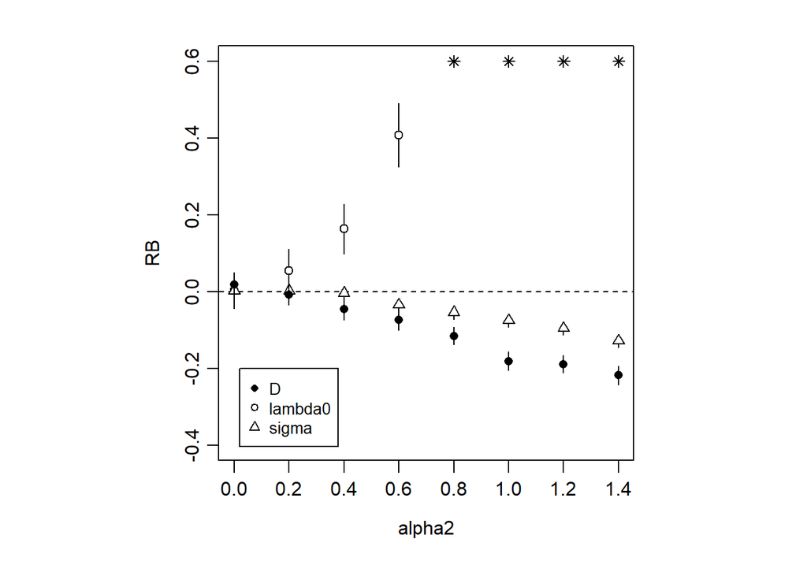

```r
leg <- c('D', 'lambda0','sigma')
alpha2 <- seq(0,1.4,0.2)
par(mfrow=c(1,1), mar=c(5,4,2,2), mgp=c(2.4,0.7,0), pty='s', bty = 'o')
plot(1,1, type = 'n', xlim=c(0,1.4), ylim=c(-0.4,0.6), xlab = 'alpha2', ylab = 'RB')
abline(h=0, lty=2)
addRB(alpha2, estL, pch=21, bg='white', star = 0.6)
addRB(alpha2, estS, pch=24, bg='white', star = 0.6)
addRB(alpha2, estD, pch=16)
legend(0.02, -0.2, legend = leg, pch=c(16,21,24), cex=0.85)
```

## Effect of normalisation

```
## Object class       capthist
## Detector type      proximity
## Detector number    49
## Average spacing    5 m
## x-range            0 30 m
## y-range            0 30 m
##
## Counts by occasion
##                    1  2  3  4  5  6  7  8  9 10 Total
## n                 11 15 13 10 10 13 10 11 14 12   119
## u                 11 14  9  6  5  7  5  3  5  4    69
## f                 34 22 11  2  0  0  0  0  0  0    69
## M(t+1)            11 25 34 40 45 52 57 60 65 69    69
## losses             0  0  0  0  0  0  0  0  0  0     0
## detections        12 15 14 10 10 13 10 11 14 12   121
## detectors visited 12 13 11  7  8 10 10 10 12 10   103
## detectors used    49 49 49 49 49 49 49 49 49 49   490
```

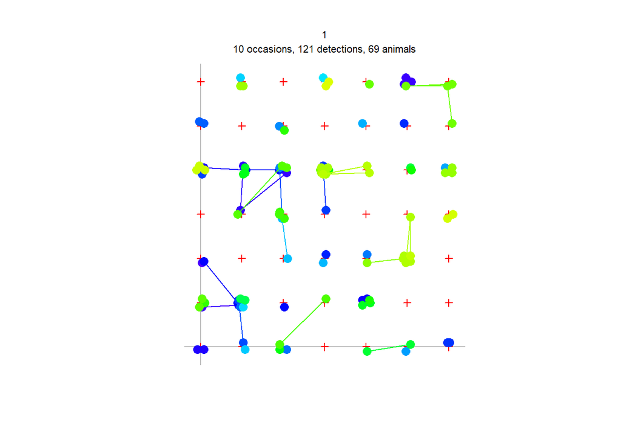

```
## [1] 1.7541
```

```r
poparg <- list(Ndist = 'fixed')
detarg <- expand.arg(alpha2        = seq(0,1.4,0.2),
                     scale         = 5,
                     normalize     = c(TRUE, FALSE))
fitarg <- list(model    = lambda0~1,
               detectfn = 'HHN',
               details  = list(distribution = 'binomial'))
scen <- make.scenarios(noccasions = 10,
                       D          = 200/maskarea(mask49),
                       lambda0    = exp(-2),
                       sigma      = 2,
                       detectfn   = 'HHN',
                       detindex   = 1:length(detarg),
                       fitindex   = 1)  # null model only
```

```r
RSFsims3 <- run.scenarios(
    nrepl       = nrepl2,
    scenarios   = scen,
    trapset     = grid49,
    maskset     = mask49,
    CH.function = "simRSFn.capthist",
    fit         = TRUE,
    pop.args    = poparg,
    det.args    = detarg,
    fit.args    = fitarg)
saveRDS(RSFsims3, file = 'RSFsims3.RDS')
```

## Results of extended simulation with normalisation

```r
RSFsims3 <- readRDS(file = 'RSFsims3.RDS')
estD <- estimateSummary(RSFsims3, 'D')
estL <- estimateSummary(RSFsims3, 'lambda0')
estS <- estimateSummary(RSFsims3, 'sigma')
cbind(alpha2 = seq(0,1.4,0.2), getcounts(RSFsims3)[,-5])
```

```
##    alpha2      n       r   nmov    dpa   rpsv
## 1     0.0 87.620  55.066 23.588 1.2689 1.8992
## 2     0.2 87.842  55.658 23.668 1.2693 1.8919
## 3     0.4 87.084  56.074 23.700 1.2723 1.8926
## 4     0.6 86.628  57.218 23.288 1.2684 1.8670
## 5     0.8 85.458  57.244 22.104 1.2581 1.8306
## 6     1.0 83.804  58.198 21.242 1.2529 1.7876
## 7     1.2 82.600  59.706 20.390 1.2463 1.7569
## 8     1.4 79.992  59.226 18.782 1.2342 1.7099
## 9     0.0 91.036  61.744 26.402 1.2899 1.9080
## 10    0.2 90.488  64.390 26.782 1.2951 1.8934
## 11    0.4 91.410  72.428 28.722 1.3122 1.8680
## 12    0.6 92.094  86.744 31.542 1.3376 1.8258
## 13    0.8 92.620 103.882 33.838 1.3585 1.7786
## 14    1.0 93.968 135.158 39.376 1.4085 1.7560
## 15    1.2 95.768 171.894 44.498 1.4506 1.7244
## 16    1.4 96.576 216.584 49.926 1.4995 1.7131
```

The number of recaptures increases radically with $\alpha_2$, but there is a much more gradual increase in dpa (detectors per animal) so we infer the increase in recaptures is due to repeat detections at favoured detectors.

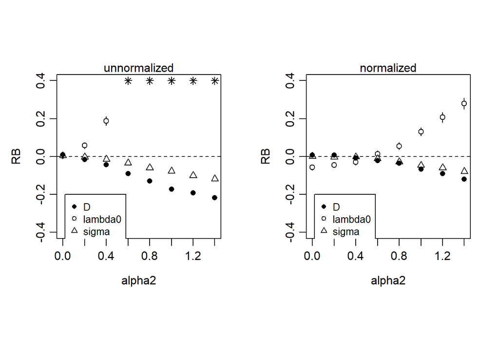

```r
leg <- c('D', 'lambda0','sigma')
alpha2 <- seq(0,1.4,0.2)
par(mfrow=c(1,2), mar=c(5,4,2,2), mgp=c(2.4,0.7,0), pty='s', bty = 'o')
for (rw in 2:1) {
    r <- (rw-1)*8+(1:8)
    plot(1,1, type = 'n', xlim=c(0,1.4), ylim=c(-0.4,0.4), xlab = 'alpha2', ylab = 'RB')
    abline(h=0, lty=2)
    addRB(alpha2, estL[r,], pch=21, bg='white', star = 0.4)
    addRB(alpha2, estS[r,], pch=24, bg='white', star = 0.4)
    addRB(alpha2, estD[r,], pch=16)
    legend(0.02, -0.2, legend = leg, pch=c(16,21,24), cex=0.85)
    mtext(side=3, c('normalized','unnormalized')[rw])
}
```

```r
grid49 <- make.grid(7,7, spacing = 5, detector = 'proximity')
mask49 <- make.mask(grid49, buffer = 8)
detarg <- expand.arg(alpha2        = seq(0,1.4,0.2),
                     scale         = c(1e-4,1e4))   # 1/phi
fitarg <- list(model    = lambda0~1,
               detectfn = 'HHN',
               details  = list(distribution = 'binomial'))
scen <- make.scenarios(noccasions = 10,
                       D          = 200/maskarea(mask49),
                       lambda0    = exp(-2),
                       sigma      = 2,
                       detectfn   = 'HHN',
                       detindex   = 1:length(detarg),
                       fitindex   = 1)  # null model only
```

```r
RSFsims4 <- run.scenarios(
    nrepl       = nrepl2,
    scenarios   = scen,
    trapset     = grid49,
    maskset     = mask49,
    CH.function = "simRSF.capthist",
    fit         = TRUE,
    pop.args    = poparg,
    det.args    = detarg,
    fit.args    = fitarg)
saveRDS(RSFsims4, file = 'RSFsims4.RDS')
```

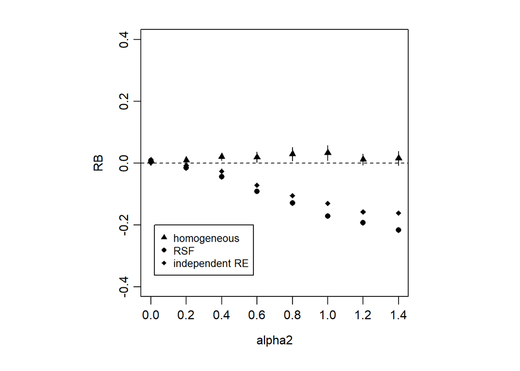

Relative bias of null-model density estimates under three scenarios for variation among detectors. ‘phi’ is the coefficient of the exponential covariance function (phi = 1/scale). Detectors are homogeneous (share the same value) when phi = 0, and independent as phi tends to infinity

```r
for (i in 1:16) for (j in nrepl:1) if (nrow(RSFsims4$output[[i]][[j]])==0) RSFsims4$output[[i]][[j]] <- NULL
estD3 <- estimateSummary(RSFsims3, 'D')
estD4 <- estimateSummary(RSFsims4, 'D', valid=c(0,5000))
leg <- c('homogeneous', 'RSF','independent RE')
alpha2 <- seq(0,1.4,0.2)
par(mfrow=c(1,1), mar=c(5,4,2,2), mgp=c(2.4,0.7,0), pty='s', bty = 'o')
plot(1,1, type = 'n', xlim=c(0,1.4), ylim=c(-0.4,0.4), xlab = 'alpha2', ylab = 'RB')
abline(h=0, lty=2)
addRB(alpha2, estD4[9:16,], pch=17)
addRB(alpha2, estD3[9:16,], pch=16)
addRB(alpha2, estD4[1:8,], pch=18)
legend(0.02, -0.2, legend = leg, pch=c(17,16,18), cex=0.85)
```